# Primer ejercicio de simulación

Fabián Brenes

8/29/2021

Estimación de los modelos VAR y VECM

```r
var <- VAR(dplyr::select(data, cpib.cri, des.sf),
           type = "both",
           lag.max = 12,
           ic = "AIC",
           exogen = dplyr::select(data, apert_comercial,
                                  cpib.usa, inflacion, tbp, vartc,
                                  est.d2, est.d3, est.d4))

vecm <- ca.jo(data %>% dplyr::select(cpib.cri, des.sf),
              type = "eigen",
              K = 5,
              dumvar = dplyr::select(data, apert_comercial, cpib.usa,
                                     inflacion, tbp, vartc,
                                     est.d2, est.d3, est.d4, tendencia),
              spec = "longrun")
vecm.level <- vec2var(vecm, 1)
```

Esta función genera los datos simulados de las variables exógenas, con base a los percentiles. Los inputs son la data original, **var** corresponde a la variable que se quiere generar datos y **q.inf** es el quantile inferior y **q.sup** el quantil superior. La función genera datos con una distribución uniforme delimitada por los percentiles que se seleccionen.

```r
generar_datos <- function(data, var, q.inf, q.sup) {

  var <- enquo(var)
  mydata <- data %>% dplyr::select(fecha, !!var) %>%
    group_by(quarter(fecha)) %>%
    summarize(lim.inf = quantile(x = !!var, q.inf),
              lim.sup = quantile(x = !!var, q.sup),
              sim = runif(1, lim.inf, lim.sup))

  return(mydata$sim)
}
```

Esta función genera las tendencia y las dummies estacionales. **fecha1** y **tendencia1** son la última fecha y tendencia real disponible. Va de 1:4, porque el modelo estima 4 periodos en un mismo momento.

```r
generar_determ <- function(fecha1, tendencia1){

  tibble(periodo = 1:4,
         fecha = add_with_rollback(fecha1, months(periodo * 3)),
         est.d2 = ifelse(quarter(fecha) == 2, 1, 0),
         est.d3 = ifelse(quarter(fecha) == 3, 1, 0),
         est.d4 = ifelse(quarter(fecha) == 4, 1, 0),
         tendencia = tendencia1 + periodo) %>%
    select(-c(periodo, fecha))
}
```

Este código genera los datos simulados. Para este ejemplo se crean 100 iteraciones. Y se estiman cuatro trimestres por iteración, para estimar un año completo.

Los percentiles escogidos para cada variable corresponden a escenarios extremos. Por ejemplo, para el caso del crecimiento del PIB de USA, se están generando datos que están entre el percentil 1% y 5%.

```r
ultima_fecha <- data$fecha[nrow(data)]
ultima_tendencia <- data$tendencia[nrow(data)]

n.iter <- 100

data_sim <- tibble(iter = 1:n.iter) %>%
  mutate(apert_comercial = map(iter, ~ generar_datos(data, apert_comercial, 0.40, 0.55)),
         cpib.usa = map(iter, ~ generar_datos(data, cpib.usa, 0.01, 0.05)),
         inflacion = map(iter, ~ generar_datos(data, inflacion, 0.75, 0.85)),
         tbp = map(iter, ~ generar_datos(data, tbp, 0.85, 0.90)),
         vartc = map(iter, ~ generar_datos(data, vartc, 0.85, 0.90)),
         determ = map(iter, ~ generar_determ(ultima_fecha, ultima_tendencia))) %>%
  unnest(-c(iter)) %>%
  nest(data_var = apert_comercial:est.d4,
       data_vecm = apert_comercial:tendencia)
```

Con la data simulada, para cada una de las iteraciones, se estiman los valores con los dos modelos.

```r
pred <- data_sim %>%
  summarize(iter = iter,
            var_pred = map(data_var, ~ predict(var, dumvar = .,
                                               n.ahead = 4)$fcst),
            vecm_pred = map(data_vecm, ~predict(vecm.level,
                                                dumvar = as.matrix(.),
                                                n.ahead = 4)$fcst)) %>%
  unnest(c(var_pred, vecm_pred)) %>%
  mutate(y = rep(c("cpib.cri", "des.sf"), n() / 2)) %>%
  unnest(c(var_pred, vecm_pred)) %>%
  pivot_longer(-c(iter, y), names_sep = "_", names_to = c("mod", "pred")) %>%
  select(-pred)
```

```r
pred_cpib <- pred %>% filter(y == "cpib.cri") %>%
  select(-y) %>%
  mutate(periodo = rep(c(rep(1, 2), rep(2, 2), rep(3, 2), rep(4, 2)), n() / 8),
         fecha = add_with_rollback(ultima_fecha, months(periodo * 3)),
         fecha.l4 = add_with_rollback(fecha, months(-12))) %>%
  left_join(data %>% select(fecha, pibr), by = c("fecha.l4" = "fecha")) %>%
  select(-periodo) %>%
  mutate(pibr.l4 = round(pibr, 2)) %>%
  select(-pibr) %>%
  mutate(`estimación puntual` = round(value[, 1], 2),
         l.inf = round(value[, 2], 2),
         l.sup = round(value[, 3], 2)) %>%
  select(-value) %>%
  pivot_longer(-c(iter, mod, fecha, fecha.l4, pibr.l4),
               names_to = "tipo", values_to = "valor") %>%
  mutate(pibr = round(exp(valor + log(pibr.l4)), 2)) %>%
  group_by(iter, mod, tipo) %>%
  mutate(pibr.anual = round(sum(pibr), 0),
         pibr.anual.l1 = round(sum(pibr.l4), 0),
         cpibr.anual.estimado = round(log(pibr.anual) - log(pibr.anual.l1), 3))
```

```r
datatable(pred_cpib)
```

|  | iter | mod | fecha | fecha.l4 | pibr.l4 | tipo | valor | pibr | pibr.anual | pibr.anual.l1 | cpibr.anual.estimado |
| --- | --- | --- | --- | --- | --- | --- | --- | --- | --- | --- | --- |
| 1 | 1 | var | 2021-03-01 | 2020-03-01 | 9059644.9 | estimación puntual | -0.07 | 8447156.92 | 31313361 | 34344121 | -0.092 |
| 2 | 1 | var | 2021-03-01 | 2020-03-01 | 9059644.9 | l.inf | -0.09 | 8279892 | 30693315 | 34344121 | -0.112 |
| 3 | 1 | var | 2021-03-01 | 2020-03-01 | 9059644.9 | l.sup | -0.04 | 8704411.14 | 32191099 | 34344121 | -0.065 |
| 4 | 1 | vecm | 2021-03-01 | 2020-03-01 | 9059644.9 | estimación puntual | -0.07 | 8447156.92 | 30929630 | 34344121 | -0.105 |
| 5 | 1 | vecm | 2021-03-01 | 2020-03-01 | 9059644.9 | l.inf | -0.08 | 8363106.3 | 30400396 | 34344121 | -0.122 |
| 6 | 1 | vecm | 2021-03-01 | 2020-03-01 | 9059644.9 | l.sup | -0.05 | 8617800.8 | 31633538 | 34344121 | -0.082 |
| 7 | 1 | var | 2021-06-01 | 2020-06-01 | 8099225.61 | estimación puntual | -0.09 | 7402134.86 | 31313361 | 34344121 | -0.092 |
| 8 | 1 | var | 2021-06-01 | 2020-06-01 | 8099225.61 | l.inf | -0.11 | 7255562.77 | 30693315 | 34344121 | -0.112 |
| 9 | 1 | var | 2021-06-01 | 2020-06-01 | 8099225.61 | l.sup | -0.07 | 7551667.9 | 32191099 | 34344121 | -0.065 |
| 10 | 1 | vecm | 2021-06-01 | 2020-06-01 | 8099225.61 | estimación puntual | -0.09 | 7402134.86 | 30929630 | 34344121 | -0.105 |

[output cut: 2390 more lines]

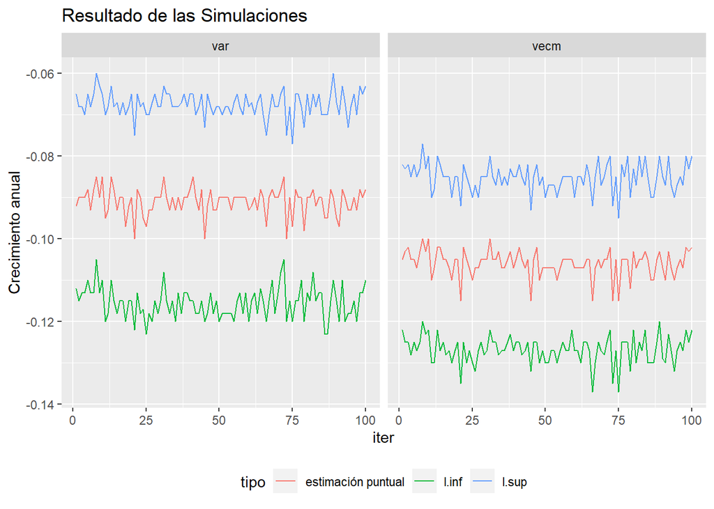

```r
pred_cpib %>%
  ggplot(aes(x = iter, y = cpibr.anual.estimado, colour = tipo)) +
  geom_line() +
  ylab("Crecimiento anual") +
  ggtitle("Resultado de las Simulaciones") +
  facet_wrap(. ~ mod) +
  theme(legend.position = "bottom")
```

```r
pred_cpib %>%
  filter(tipo == "estimación puntual") %>%
  group_by(mod) %>%
  summarize(mediana = round(median(cpibr.anual.estimado), 4)) %>%
  knitr::kable(booktabs = TRUE,
               caption = "Mediana de la estimación puntual",
               format = "html") %>%
  kable_styling(latex_options = "scale_down", full_width = F,
                font_size = 15) %>%
  column_spec(1, width = "5em") %>%
  column_spec(2, width = "10em")
```

Mediana de la estimación puntual

| mod | mediana |
| --- | --- |
| var | -0.090 |
| vecm | -0.105 |